# Heart AI Comparison

Bruce Hartman

Last updated: 01 December, 2023

# Introduction

We will look at linear regression and compare some other AI methods to analyze the Heart data. In this notebook we will introduce one-hot coding for the categorical drivers, and build the models with this encoded data.

# Packages

Loading the standard packages for this course:

```r
library(tidyverse) # used to manipulate data and plot
library(ISLR2) #package contains the data files, but not this one
library(ggfortify) # some extra ggplot functions
library(GGally) # pairs ggplot and other options
library(flextable) # nice displays of printed data
library(DT) #more nice table displays from RStudio
library(broom) # neat model summary
library(car) # useful tools for regression analysis
library(MASS) # for LDA analysis
library(class) # for knn analysis
library(caret) # for confusion matrix and for crossvalidation
library(mltools) # collection of machine learning tools
```

# Data

We will load the Heart data from a csv file in the data folder. We will use the Import Dataset button in the upper right panel. We will be sure to copy the code generated and place it in the notebook, so the notebook can run on its own.

```r
library(readr)
Heart <- read_csv("~/stfrancis/MBAD640 Data Mining/Course Files MBAD 640/Data Sets/Heart.csv")
Heart %>% glimpse
```

```
Rows: 303
Columns: 15
$ ...1      <dbl> 1, 2, 3, 4, 5, 6, 7, 8, 9, 10, 11, 12, 13, 14, 15, 16, 17, 18, 19, 20, 21, 22, 23, 2…
$ Age       <dbl> 63, 67, 67, 37, 41, 56, 62, 57, 63, 53, 57, 56, 56, 44, 52, 57, 48, 54, 48, 49, 64, …
$ Sex       <dbl> 1, 1, 1, 1, 0, 1, 0, 0, 1, 1, 1, 0, 1, 1, 1, 1, 1, 1, 0, 1, 1, 0, 1, 1, 1, 0, 0, 0, …
$ ChestPain <chr> "typical", "asymptomatic", "asymptomatic", "nonanginal", "nontypical", "nontypical",…
$ RestBP    <dbl> 145, 160, 120, 130, 130, 120, 140, 120, 130, 140, 140, 140, 130, 120, 172, 150, 110,…
$ Chol      <dbl> 233, 286, 229, 250, 204, 236, 268, 354, 254, 203, 192, 294, 256, 263, 199, 168, 229,…
$ Fbs       <dbl> 1, 0, 0, 0, 0, 0, 0, 0, 0, 1, 0, 0, 1, 0, 1, 0, 0, 0, 0, 0, 0, 1, 0, 0, 0, 0, 0, 0, …
$ RestECG   <dbl> 2, 2, 2, 0, 2, 0, 2, 0, 2, 2, 0, 2, 2, 0, 0, 0, 0, 0, 0, 0, 2, 2, 2, 2, 2, 0, 0, 0, …
$ MaxHR     <dbl> 150, 108, 129, 187, 172, 178, 160, 163, 147, 155, 148, 153, 142, 173, 162, 174, 168,…
$ ExAng     <dbl> 0, 1, 1, 0, 0, 0, 0, 1, 0, 1, 0, 0, 1, 0, 0, 0, 0, 0, 0, 0, 1, 0, 0, 0, 1, 0, 0, 0, …
$ Oldpeak   <dbl> 2.3, 1.5, 2.6, 3.5, 1.4, 0.8, 3.6, 0.6, 1.4, 3.1, 0.4, 1.3, 0.6, 0.0, 0.5, 1.6, 1.0,…
$ Slope     <dbl> 3, 2, 2, 3, 1, 1, 3, 1, 2, 3, 2, 2, 2, 1, 1, 1, 3, 1, 1, 1, 2, 1, 2, 1, 2, 2, 1, 3, …
$ Ca        <dbl> 0, 3, 2, 0, 0, 0, 2, 0, 1, 0, 0, 0, 1, 0, 0, 0, 0, 0, 0, 0, 0, 0, 0, 2, 2, 0, 0, 0, …
$ Thal      <chr> "fixed", "normal", "reversable", "normal", "normal", "normal", "normal", "normal", "…
$ AHD       <chr> "No", "Yes", "Yes", "No", "No", "No", "Yes", "No", "Yes", "Yes", "No", "No", "Yes", …
```

```r
Heart
```

| ...1 | Age | Sex | ChestPain | RestBP | Chol | Fbs | RestECG | MaxHR | ExAng | Oldpeak | Slope | Ca | Thal | AHD |
| --- | --- | --- | --- | --- | --- | --- | --- | --- | --- | --- | --- | --- | --- | --- |
| 1 | 63 | 1 | typical | 145 | 233 | 1 | 2 | 150 | 0 | 2.3 | 3 | 0 | fixed | No |
| 2 | 67 | 1 | asymptomatic | 160 | 286 | 0 | 2 | 108 | 1 | 1.5 | 2 | 3 | normal | Yes |
| 3 | 67 | 1 | asymptomatic | 120 | 229 | 0 | 2 | 129 | 1 | 2.6 | 2 | 2 | reversable | Yes |
| 4 | 37 | 1 | nonanginal | 130 | 250 | 0 | 0 | 187 | 0 | 3.5 | 3 | 0 | normal | No |
| 5 | 41 | 0 | nontypical | 130 | 204 | 0 | 2 | 172 | 0 | 1.4 | 1 | 0 | normal | No |
| 6 | 56 | 1 | nontypical | 120 | 236 | 0 | 0 | 178 | 0 | 0.8 | 1 | 0 | normal | No |
| 7 | 62 | 0 | asymptomatic | 140 | 268 | 0 | 2 | 160 | 0 | 3.6 | 3 | 2 | normal | Yes |
| 8 | 57 | 0 | asymptomatic | 120 | 354 | 0 | 0 | 163 | 1 | 0.6 | 1 | 0 | normal | No |
| 9 | 63 | 1 | asymptomatic | 130 | 254 | 0 | 2 | 147 | 0 | 1.4 | 2 | 1 | reversable | Yes |
| 10 | 53 | 1 | asymptomatic | 140 | 203 | 1 | 2 | 155 | 1 | 3.1 | 3 | 0 | reversable | Yes |

[output cut: 293 more lines]

You can see that the first column has a funny name. It seems to just count the observations, all 303 of them. Let’s change the name of the first column to `Obs` for observation.

```r
names(Heart)[1]="Obs"
Heart
```

| Obs | Age | Sex | ChestPain | RestBP | Chol | Fbs | RestECG | MaxHR | ExAng | Oldpeak | Slope | Ca | Thal | AHD |
| --- | --- | --- | --- | --- | --- | --- | --- | --- | --- | --- | --- | --- | --- | --- |
| 1 | 63 | 1 | typical | 145 | 233 | 1 | 2 | 150 | 0 | 2.3 | 3 | 0 | fixed | No |
| 2 | 67 | 1 | asymptomatic | 160 | 286 | 0 | 2 | 108 | 1 | 1.5 | 2 | 3 | normal | Yes |
| 3 | 67 | 1 | asymptomatic | 120 | 229 | 0 | 2 | 129 | 1 | 2.6 | 2 | 2 | reversable | Yes |
| 4 | 37 | 1 | nonanginal | 130 | 250 | 0 | 0 | 187 | 0 | 3.5 | 3 | 0 | normal | No |
| 5 | 41 | 0 | nontypical | 130 | 204 | 0 | 2 | 172 | 0 | 1.4 | 1 | 0 | normal | No |
| 6 | 56 | 1 | nontypical | 120 | 236 | 0 | 0 | 178 | 0 | 0.8 | 1 | 0 | normal | No |
| 7 | 62 | 0 | asymptomatic | 140 | 268 | 0 | 2 | 160 | 0 | 3.6 | 3 | 2 | normal | Yes |
| 8 | 57 | 0 | asymptomatic | 120 | 354 | 0 | 0 | 163 | 1 | 0.6 | 1 | 0 | normal | No |
| 9 | 63 | 1 | asymptomatic | 130 | 254 | 0 | 2 | 147 | 0 | 1.4 | 2 | 1 | reversable | Yes |
| 10 | 53 | 1 | asymptomatic | 140 | 203 | 1 | 2 | 155 | 1 | 3.1 | 3 | 0 | reversable | Yes |

[output cut: 293 more lines]

# Data Description

It is always a good idea to run a `summary()` of the data.

```r
Heart %>% summary
```

```
      Obs             Age             Sex          ChestPain             RestBP           Chol
 Min.   :  1.0   Min.   :29.00   Min.   :0.0000   Length:303         Min.   : 94.0   Min.   :126.0
 1st Qu.: 76.5   1st Qu.:48.00   1st Qu.:0.0000   Class :character   1st Qu.:120.0   1st Qu.:211.0
 Median :152.0   Median :56.00   Median :1.0000   Mode  :character   Median :130.0   Median :241.0
 Mean   :152.0   Mean   :54.44   Mean   :0.6799                      Mean   :131.7   Mean   :246.7
 3rd Qu.:227.5   3rd Qu.:61.00   3rd Qu.:1.0000                      3rd Qu.:140.0   3rd Qu.:275.0
 Max.   :303.0   Max.   :77.00   Max.   :1.0000                      Max.   :200.0   Max.   :564.0

      Fbs            RestECG           MaxHR           ExAng           Oldpeak         Slope
 Min.   :0.0000   Min.   :0.0000   Min.   : 71.0   Min.   :0.0000   Min.   :0.00   Min.   :1.000
 1st Qu.:0.0000   1st Qu.:0.0000   1st Qu.:133.5   1st Qu.:0.0000   1st Qu.:0.00   1st Qu.:1.000
 Median :0.0000   Median :1.0000   Median :153.0   Median :0.0000   Median :0.80   Median :2.000
 Mean   :0.1485   Mean   :0.9901   Mean   :149.6   Mean   :0.3267   Mean   :1.04   Mean   :1.601
 3rd Qu.:0.0000   3rd Qu.:2.0000   3rd Qu.:166.0   3rd Qu.:1.0000   3rd Qu.:1.60   3rd Qu.:2.000
 Max.   :1.0000   Max.   :2.0000   Max.   :202.0   Max.   :1.0000   Max.   :6.20   Max.   :3.000

       Ca             Thal               AHD
 Min.   :0.0000   Length:303         Length:303
 1st Qu.:0.0000   Class :character   Class :character
 Median :0.0000   Mode  :character   Mode  :character
 Mean   :0.6722
 3rd Qu.:1.0000
 Max.   :3.0000
 NA's   :4
```

# Data Wrangling

There are some missing data. There are several character variables that should be turned into factors, and some 0-1 variables that should also be factors.

```r
Heart %>% glimpse
```

```
Rows: 297
Columns: 15
$ Obs       <dbl> 1, 2, 3, 4, 5, 6, 7, 8, 9, 10, 11, 12, 13, 14, 15, 16, 17, 18, 19, 20,…
$ Age       <dbl> 63, 67, 67, 37, 41, 56, 62, 57, 63, 53, 57, 56, 56, 44, 52, 57, 48, 54…
$ Sex       <fct> 1, 1, 1, 1, 0, 1, 0, 0, 1, 1, 1, 0, 1, 1, 1, 1, 1, 1, 0, 1, 1, 0, 1, 1…
$ ChestPain <fct> typical, asymptomatic, asymptomatic, nonanginal, nontypical, nontypica…
$ RestBP    <dbl> 145, 160, 120, 130, 130, 120, 140, 120, 130, 140, 140, 140, 130, 120, …
$ Chol      <dbl> 233, 286, 229, 250, 204, 236, 268, 354, 254, 203, 192, 294, 256, 263, …
$ Fbs       <fct> 1, 0, 0, 0, 0, 0, 0, 0, 0, 1, 0, 0, 1, 0, 1, 0, 0, 0, 0, 0, 0, 1, 0, 0…
$ RestECG   <fct> 2, 2, 2, 0, 2, 0, 2, 0, 2, 2, 0, 2, 2, 0, 0, 0, 0, 0, 0, 0, 2, 2, 2, 2…
$ MaxHR     <dbl> 150, 108, 129, 187, 172, 178, 160, 163, 147, 155, 148, 153, 142, 173, …
$ ExAng     <fct> 0, 1, 1, 0, 0, 0, 0, 1, 0, 1, 0, 0, 1, 0, 0, 0, 0, 0, 0, 0, 1, 0, 0, 0…
$ Oldpeak   <dbl> 2.3, 1.5, 2.6, 3.5, 1.4, 0.8, 3.6, 0.6, 1.4, 3.1, 0.4, 1.3, 0.6, 0.0, …
$ Slope     <fct> 3, 2, 2, 3, 1, 1, 3, 1, 2, 3, 2, 2, 2, 1, 1, 1, 3, 1, 1, 1, 2, 1, 2, 1…
$ Ca        <fct> 0, 3, 2, 0, 0, 0, 2, 0, 1, 0, 0, 0, 1, 0, 0, 0, 0, 0, 0, 0, 0, 0, 0, 2…
$ Thal      <fct> fixed, normal, reversable, normal, normal, normal, normal, normal, rev…
$ AHD       <fct> No, Yes, Yes, No, No, No, Yes, No, Yes, Yes, No, No, Yes, No, No, No, …
```

# One-Hot Encoding

For machine learning applications it is helpful to make factor drivers into multiple dummy variables. This process is called one-hot encoding. If a factor has $n$ levels, there will be $n$ dummy variables created, one for each level of the factor. The dataset can then be treated as all numeric. The disadvantage is there are many more drivers, but faster computers and better algorithms handle that nicely.

We will create a one-hot encoded version of the data. the right function is in the `mltools` package.

There are now 31 columns, and all the dummy columns can be seen as separate drivers.

```r
Heartoh %>% summary
```

```
      Obs             Age            Sex_0            Sex_1        ChestPain_asymptomatic
 Min.   :  1.0   Min.   :29.00   Min.   :0.0000   Min.   :0.0000   Min.   :0.0000
 1st Qu.: 75.0   1st Qu.:48.00   1st Qu.:0.0000   1st Qu.:0.0000   1st Qu.:0.0000
 Median :150.0   Median :56.00   Median :0.0000   Median :1.0000   Median :0.0000
 Mean   :150.7   Mean   :54.54   Mean   :0.3232   Mean   :0.6768   Mean   :0.4781
 3rd Qu.:226.0   3rd Qu.:61.00   3rd Qu.:1.0000   3rd Qu.:1.0000   3rd Qu.:1.0000
 Max.   :302.0   Max.   :77.00   Max.   :1.0000   Max.   :1.0000   Max.   :1.0000
 ChestPain_nonanginal ChestPain_nontypical ChestPain_typical     RestBP
 Min.   :0.0000       Min.   :0.000        Min.   :0.00000   Min.   : 94.0
 1st Qu.:0.0000       1st Qu.:0.000        1st Qu.:0.00000   1st Qu.:120.0
 Median :0.0000       Median :0.000        Median :0.00000   Median :130.0
 Mean   :0.2795       Mean   :0.165        Mean   :0.07744   Mean   :131.7
 3rd Qu.:1.0000       3rd Qu.:0.000        3rd Qu.:0.00000   3rd Qu.:140.0
 Max.   :1.0000       Max.   :1.000        Max.   :1.00000   Max.   :200.0
      Chol           Fbs_0            Fbs_1          RestECG_0        RestECG_1
 Min.   :126.0   Min.   :0.0000   Min.   :0.0000   Min.   :0.0000   Min.   :0.00000
 1st Qu.:211.0   1st Qu.:1.0000   1st Qu.:0.0000   1st Qu.:0.0000   1st Qu.:0.00000
 Median :243.0   Median :1.0000   Median :0.0000   Median :0.0000   Median :0.00000
 Mean   :247.4   Mean   :0.8552   Mean   :0.1448   Mean   :0.4949   Mean   :0.01347
 3rd Qu.:276.0   3rd Qu.:1.0000   3rd Qu.:0.0000   3rd Qu.:1.0000   3rd Qu.:0.00000
 Max.   :564.0   Max.   :1.0000   Max.   :1.0000   Max.   :1.0000   Max.   :1.00000
   RestECG_2          MaxHR          ExAng_0          ExAng_1          Oldpeak
 Min.   :0.0000   Min.   : 71.0   Min.   :0.0000   Min.   :0.0000   Min.   :0.000
 1st Qu.:0.0000   1st Qu.:133.0   1st Qu.:0.0000   1st Qu.:0.0000   1st Qu.:0.000
 Median :0.0000   Median :153.0   Median :1.0000   Median :0.0000   Median :0.800
 Mean   :0.4916   Mean   :149.6   Mean   :0.6734   Mean   :0.3266   Mean   :1.056
 3rd Qu.:1.0000   3rd Qu.:166.0   3rd Qu.:1.0000   3rd Qu.:1.0000   3rd Qu.:1.600
 Max.   :1.0000   Max.   :202.0   Max.   :1.0000   Max.   :1.0000   Max.   :6.200
    Slope_1         Slope_2          Slope_3             Ca_0             Ca_1
 Min.   :0.000   Min.   :0.0000   Min.   :0.00000   Min.   :0.0000   Min.   :0.0000
 1st Qu.:0.000   1st Qu.:0.0000   1st Qu.:0.00000   1st Qu.:0.0000   1st Qu.:0.0000
 Median :0.000   Median :0.0000   Median :0.00000   Median :1.0000   Median :0.0000
 Mean   :0.468   Mean   :0.4613   Mean   :0.07071   Mean   :0.5859   Mean   :0.2189
 3rd Qu.:1.000   3rd Qu.:1.0000   3rd Qu.:0.00000   3rd Qu.:1.0000   3rd Qu.:0.0000
 Max.   :1.000   Max.   :1.0000   Max.   :1.00000   Max.   :1.0000   Max.   :1.0000
      Ca_2             Ca_3           Thal_fixed       Thal_normal     Thal_reversable
 Min.   :0.0000   Min.   :0.00000   Min.   :0.00000   Min.   :0.0000   Min.   :0.0000
 1st Qu.:0.0000   1st Qu.:0.00000   1st Qu.:0.00000   1st Qu.:0.0000   1st Qu.:0.0000
 Median :0.0000   Median :0.00000   Median :0.00000   Median :1.0000   Median :0.0000
 Mean   :0.1279   Mean   :0.06734   Mean   :0.06061   Mean   :0.5522   Mean   :0.3872
 3rd Qu.:0.0000   3rd Qu.:0.00000   3rd Qu.:0.00000   3rd Qu.:1.0000   3rd Qu.:1.0000
 Max.   :1.0000   Max.   :1.00000   Max.   :1.00000   Max.   :1.0000   Max.   :1.0000
     AHD_No          AHD_Yes
 Min.   :0.0000   Min.   :0.0000
 1st Qu.:0.0000   1st Qu.:0.0000
 Median :1.0000   Median :0.0000
 Mean   :0.5387   Mean   :0.4613
 3rd Qu.:1.0000   3rd Qu.:1.0000
 Max.   :1.0000   Max.   :1.0000
```

```r
Heartoh %>% glimpse
```

```
Rows: 297
Columns: 31
$ Obs                    <dbl> 1, 2, 3, 4, 5, 6, 7, 8, 9, 10, 11, 12, 13, 14, 15, 16, 17…
$ Age                    <dbl> 63, 67, 67, 37, 41, 56, 62, 57, 63, 53, 57, 56, 56, 44, 5…
$ Sex_0                  <int> 0, 0, 0, 0, 1, 0, 1, 1, 0, 0, 0, 1, 0, 0, 0, 0, 0, 0, 1, …
$ Sex_1                  <int> 1, 1, 1, 1, 0, 1, 0, 0, 1, 1, 1, 0, 1, 1, 1, 1, 1, 1, 0, …
$ ChestPain_asymptomatic <int> 0, 1, 1, 0, 0, 0, 1, 1, 1, 1, 1, 0, 0, 0, 0, 0, 0, 1, 0, …
$ ChestPain_nonanginal   <int> 0, 0, 0, 1, 0, 0, 0, 0, 0, 0, 0, 0, 1, 0, 1, 1, 0, 0, 1, …
$ ChestPain_nontypical   <int> 0, 0, 0, 0, 1, 1, 0, 0, 0, 0, 0, 1, 0, 1, 0, 0, 1, 0, 0, …
$ ChestPain_typical      <int> 1, 0, 0, 0, 0, 0, 0, 0, 0, 0, 0, 0, 0, 0, 0, 0, 0, 0, 0, …
$ RestBP                 <dbl> 145, 160, 120, 130, 130, 120, 140, 120, 130, 140, 140, 14…
$ Chol                   <dbl> 233, 286, 229, 250, 204, 236, 268, 354, 254, 203, 192, 29…
$ Fbs_0                  <int> 0, 1, 1, 1, 1, 1, 1, 1, 1, 0, 1, 1, 0, 1, 0, 1, 1, 1, 1, …
$ Fbs_1                  <int> 1, 0, 0, 0, 0, 0, 0, 0, 0, 1, 0, 0, 1, 0, 1, 0, 0, 0, 0, …
$ RestECG_0              <int> 0, 0, 0, 1, 0, 1, 0, 1, 0, 0, 1, 0, 0, 1, 1, 1, 1, 1, 1, …
```

[output cut: 18 more lines]

# Research Problem

The research problem is to compare predictions of RestBP from the other variables, using linear regression and other AI methods.

We will compare accuracy of the methods using root-mean squared error or RMSE, which can be computed from the predictions and the actual values of RestBP in the dataset. Note that we cannot compare AI methods directly with linear regression using anova, since the methods use totally different techniques.

# Data Visualization

We plot RestBP with some other variables.

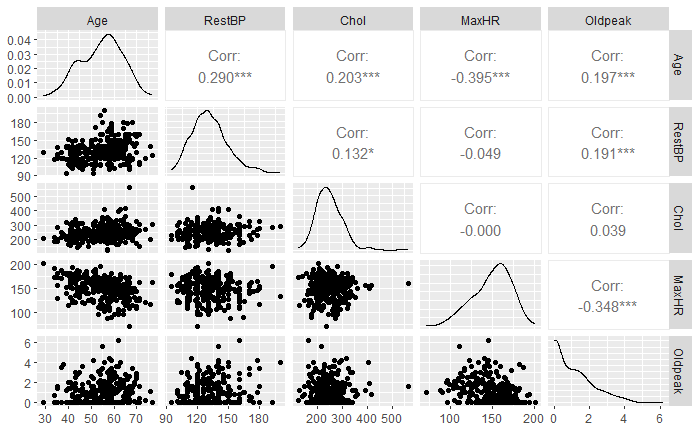

```r
Heart %>% dplyr::select(where(is.numeric) & !contains("Obs")) %>%
  ggpairs(progress=F)
```

We see some dependency of RestBP (second row and column) n the others, but it’s hard to find a pattern.

Next we try the non-numeric factor variables. No correlation coefficients can be computed.

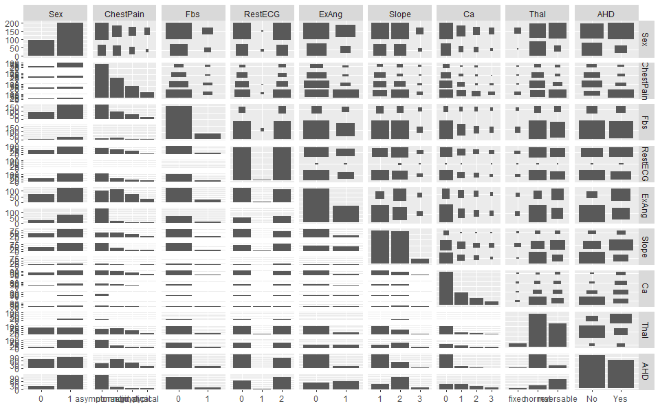

```r
Heart %>% dplyr::select(where(is.factor) & !contains("Obs")) %>%
  ggpairs(progress=F)
```

Not pretty, but shows relative proportions of each variable with the others. Hard to read.

# Wrangling for Analysis (deprecated)

For our analysis we need all the data to be numeric. We will convert all the factor variables to numeric. Columns with several values will be converted to several consecutive integer values; binary factors will be converted to 1-2.

```r
Heartall = Heart %>%
  dplyr::select(!contains("Obs")) %>%
  sapply(FUN= as.numeric) %>% data.frame
Heartall
```

| Age | Sex | ChestPain | RestBP | Chol | Fbs | RestECG | MaxHR | ExAng | Oldpeak | Slope | Ca | Thal | AHD |
| --- | --- | --- | --- | --- | --- | --- | --- | --- | --- | --- | --- | --- | --- |
| 63 | 2 | 4 | 145 | 233 | 2 | 3 | 150 | 1 | 2.3 | 3 | 1 | 1 | 1 |
| 67 | 2 | 1 | 160 | 286 | 1 | 3 | 108 | 2 | 1.5 | 2 | 4 | 2 | 2 |
| 67 | 2 | 1 | 120 | 229 | 1 | 3 | 129 | 2 | 2.6 | 2 | 3 | 3 | 2 |
| 37 | 2 | 2 | 130 | 250 | 1 | 1 | 187 | 1 | 3.5 | 3 | 1 | 2 | 1 |
| 41 | 1 | 3 | 130 | 204 | 1 | 3 | 172 | 1 | 1.4 | 1 | 1 | 2 | 1 |
| 56 | 2 | 3 | 120 | 236 | 1 | 1 | 178 | 1 | 0.8 | 1 | 1 | 2 | 1 |
| 62 | 1 | 1 | 140 | 268 | 1 | 3 | 160 | 1 | 3.6 | 3 | 3 | 2 | 2 |
| 57 | 1 | 1 | 120 | 354 | 1 | 1 | 163 | 2 | 0.6 | 1 | 1 | 2 | 1 |
| 63 | 2 | 1 | 130 | 254 | 1 | 3 | 147 | 1 | 1.4 | 2 | 2 | 3 | 2 |
| 53 | 2 | 1 | 140 | 203 | 2 | 3 | 155 | 2 | 3.1 | 3 | 1 | 3 | 2 |

[output cut: 287 more lines]

All columns are now numeric.

We will save this numeric data for use elsewhere.

```r
saveRDS(Heartall, file="Heartall.rds")
```

For analysis we will use the one-hot encoded dataframe `Heartoh`.

# Analysis

We will use linear regression first.

## Linear Regression

As a measure of accuracy we are going to use RMSE. The mltools package has functions for computing most of the common measures.

```r
fit.lm.all = lm(RestBP~.-Obs, data=Heartoh)
fit.lm.all %>% summary %>% tidy() %>% mutate(" "=pvstars(fit.lm.all), .after=p.value)
```

| term | estimate | std.error | statistic | p.value |  |
| --- | --- | --- | --- | --- | --- |
| (Intercept) | 103.43101102 | 15.16092954 | 6.82220775 | 5.663608e-11 | *** |
| Age | 0.54022767 | 0.12705934 | 4.25177447 | 2.905480e-05 | *** |
| Sex_0 | 5.19785943 | 2.39636658 | 2.16905855 | 3.093199e-02 | * |
| ChestPain_asymptomatic | -9.54397650 | 4.00872586 | -2.38080049 | 1.795378e-02 | * |
| ChestPain_nonanginal | -8.41164730 | 3.99805288 | -2.10393598 | 3.628869e-02 | * |
| ChestPain_nontypical | -7.68240736 | 4.34823992 | -1.76678553 | 7.836937e-02 | . |
| Chol | 0.01393527 | 0.01971359 | 0.70688665 | 4.802333e-01 |  |
| Fbs_0 | -6.75338912 | 2.85750356 | -2.36338782 | 1.880196e-02 | * |
| RestECG_0 | -2.81134098 | 2.01968211 | -1.39197202 | 1.650515e-01 |  |
| RestECG_1 | 0.99714794 | 8.61033832 | 0.11580822 | 9.078888e-01 |  |

[output cut: 11 more lines]

```r
fit.lm.all %>% summary %>% glance()
```

| r.squared | adj.r.squared | sigma | statistic | p.value | df | df.residual | nobs |
| --- | --- | --- | --- | --- | --- | --- | --- |
| 0.2043291 | 0.1466718 | 16.40853 | 3.543854 | 1.129182e-06 | 20 | 276 | 297 |

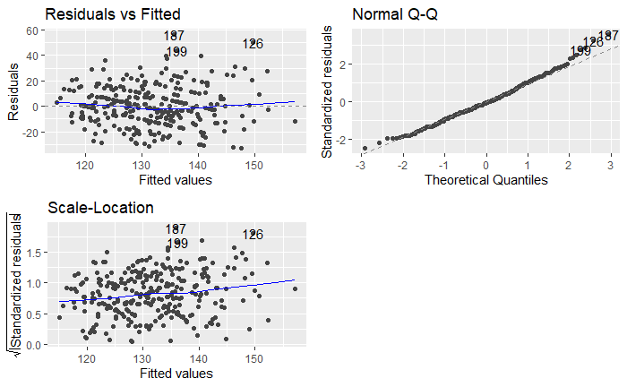

```r
fit.lm.all %>% autoplot(which=1:3)
```

```r
accuracy.rmse.lm.all = mltools::rmse(predict(fit.lm.all, newdata=Heartoh), Heartoh$RestBP)
accuracy.rmse.lm.all
```

```
[1] 15.8178
```

The RMSE is 15.8177952.

### Visualization

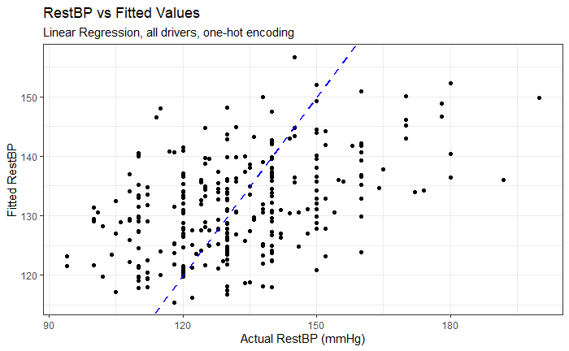

```r
plot.lm.all = ggplot(Heartoh) +
  geom_point(aes(RestBP, fit.lm.all$fitted.values))+
  geom_abline(aes(slope=1, intercept=0), color="blue", linetype="dashed", linewidth=1) +
  theme_bw() +
  labs(title="RestBP vs Fitted Values",
       subtitle="Linear Regression, all drivers, one-hot encoding",
       x="Actual RestBP (mmHg)", y="Fitted RestBP")
plot.lm.all
```

## Neural Network

For a neural network it is important to scale the variables, like to a 0-1 range. We do this by taking each value and subtracting from it the minimum of the column, then dividing by max - min of the column. When we get predictions, we will have to unscale them to compare them to the linear model.

```r
Heartoh.scaled = Heartoh %>% sapply(FUN = function (x) {
  (x-min(x))/(max(x)-min(x))})  %>% data.frame
Heartoh.scaled %>% glimpse
```

```
Rows: 297
Columns: 31
$ Obs                    <dbl> 0.000000000, 0.003322259, 0.006644518, 0.009966777, 0.013…
$ Age                    <dbl> 0.7083333, 0.7916667, 0.7916667, 0.1666667, 0.2500000, 0.…
$ Sex_0                  <dbl> 0, 0, 0, 0, 1, 0, 1, 1, 0, 0, 0, 1, 0, 0, 0, 0, 0, 0, 1, …
$ Sex_1                  <dbl> 1, 1, 1, 1, 0, 1, 0, 0, 1, 1, 1, 0, 1, 1, 1, 1, 1, 1, 0, …
$ ChestPain_asymptomatic <dbl> 0, 1, 1, 0, 0, 0, 1, 1, 1, 1, 1, 0, 0, 0, 0, 0, 0, 1, 0, …
$ ChestPain_nonanginal   <dbl> 0, 0, 0, 1, 0, 0, 0, 0, 0, 0, 0, 0, 1, 0, 1, 1, 0, 0, 1, …
$ ChestPain_nontypical   <dbl> 0, 0, 0, 0, 1, 1, 0, 0, 0, 0, 0, 1, 0, 1, 0, 0, 1, 0, 0, …
$ ChestPain_typical      <dbl> 1, 0, 0, 0, 0, 0, 0, 0, 0, 0, 0, 0, 0, 0, 0, 0, 0, 0, 0, …
$ RestBP                 <dbl> 0.4811321, 0.6226415, 0.2452830, 0.3396226, 0.3396226, 0.…
$ Chol                   <dbl> 0.24429224, 0.36529680, 0.23515982, 0.28310502, 0.1780821…
$ Fbs_0                  <dbl> 0, 1, 1, 1, 1, 1, 1, 1, 1, 0, 1, 1, 0, 1, 0, 1, 1, 1, 1, …
$ Fbs_1                  <dbl> 1, 0, 0, 0, 0, 0, 0, 0, 0, 1, 0, 0, 1, 0, 1, 0, 0, 0, 0, …
$ RestECG_0              <dbl> 0, 0, 0, 1, 0, 1, 0, 1, 0, 0, 1, 0, 0, 1, 1, 1, 1, 1, 1, …
```

[output cut: 18 more lines]

Run 3 repetitions of the same neural net.

```r
library(neuralnet)
fit.nn.all= neuralnet(RestBP~.-Obs, data=Heartoh.scaled, linear.output=F,
                      hidden=c(5,3), rep=3)
```

Display the neuralnet.

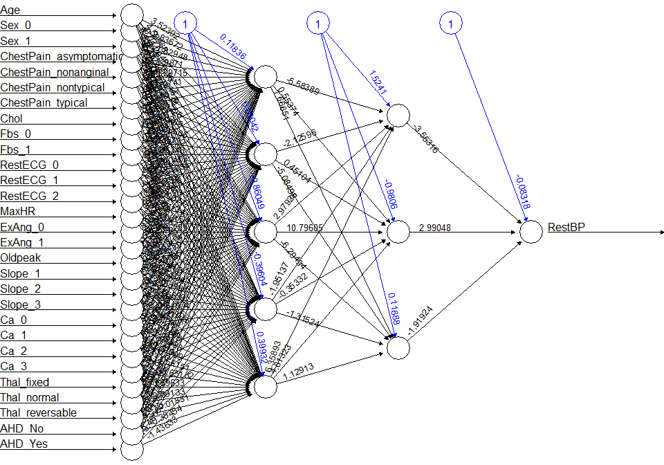

```r
fit.nn.all %>% plot(rep='best')
```

It’s a busy plot on the left because there are so many drivers. Make predictions and unscale them.

```r
pred.nn.all = predict(fit.nn.all, newdata=Heartoh.scaled)
pred.nn.all %>% summary
```

```
       V1
 Min.   :0.05628
 1st Qu.:0.26093
 Median :0.33511
 Mean   :0.35441
 3rd Qu.:0.41744
 Max.   :0.86628
```

```r
pred.nn.all.unscaled = min(Heartoh$RestBP) + (max(Heartoh$RestBP)-min(Heartoh$RestBP))*pred.nn.all
pred.nn.all.unscaled %>% summary
```

```
       V1
 Min.   : 99.97
 1st Qu.:121.66
 Median :129.52
 Mean   :131.57
 3rd Qu.:138.25
 Max.   :185.83
```

Compute accuracy now.

```r
accuracy.rmse.nn.all = mltools::rmse(pred.nn.all.unscaled, Heartoh$RestBP)
accuracy.rmse.nn.all
```

```
[1] 10.53352
```

All the drivers give an RMSE of 10.5335158.

### Visualization

All drivers including discrete ones.

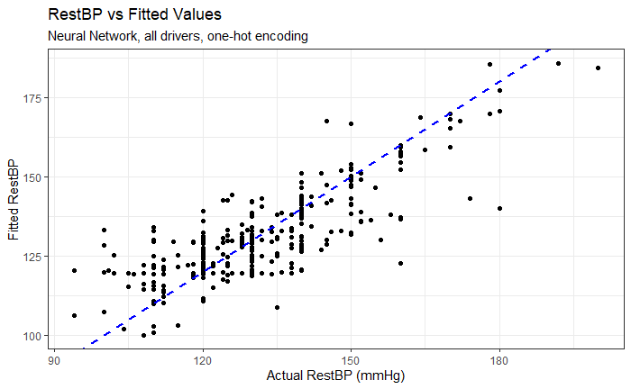

```r
plot.nn.all = ggplot(Heartoh) +
  geom_point(aes(RestBP, pred.nn.all.unscaled))+
  geom_abline(aes(slope=1, intercept=0), color="blue", linetype="dashed", linewidth=1) +
  theme_bw() +
  labs(title="RestBP vs Fitted Values",
       subtitle="Neural Network, all drivers, one-hot encoding",
       x="Actual RestBP (mmHg)", y="Fitted RestBP")
plot.nn.all
```